# Travel Package Purchase Prediction

### MaritalStatus vs Prod Taken

```
ProdTaken         0    1   All
MaritalStatus
All            3968  920  4888
Married        2014  326  2340
Single          612  304   916
Unmarried       516  166   682
Divorced        826  124   950
------------------------------------------------------------------------------------------------------------------------
```

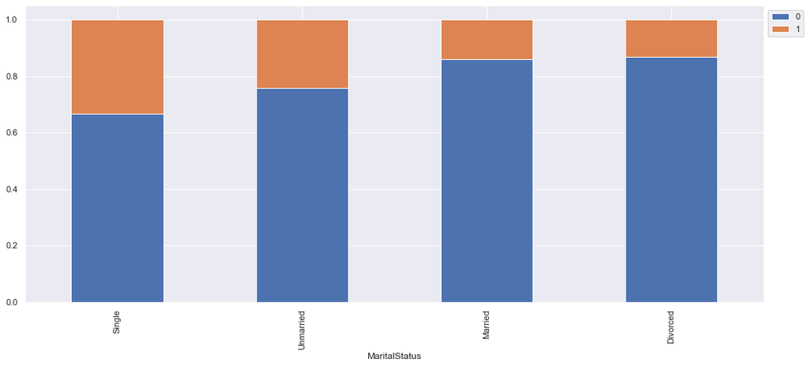

```python
stacked_plot(data['MaritalStatus'])
```

- Proportionaly, Single category in `MaritalStatus` is the most successfull.

### NumberOfTrips vs Prod Taken

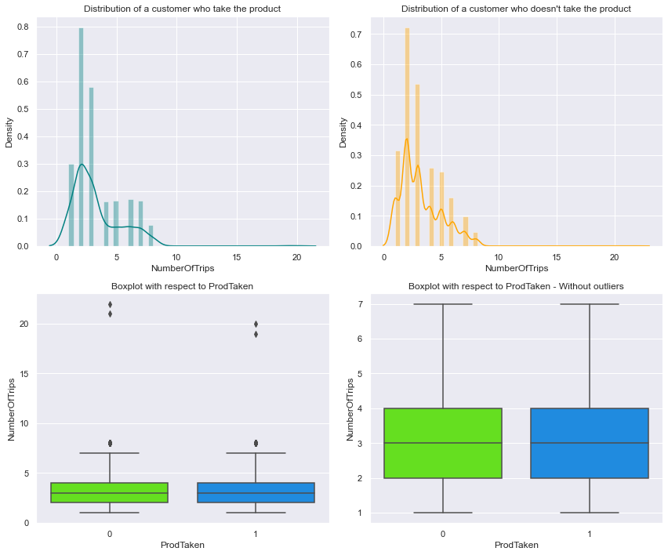

```python
dist_catplot('NumberOfTrips')
```

- There is no major difference in `NumberOfTrips` in regards to ProdTaken.

### Passport vs Prod Taken

```
ProdTaken     0    1   All
Passport
All        3968  920  4888
1           928  494  1422
0          3040  426  3466
------------------------------------------------------------------------------------------------------------------------
```

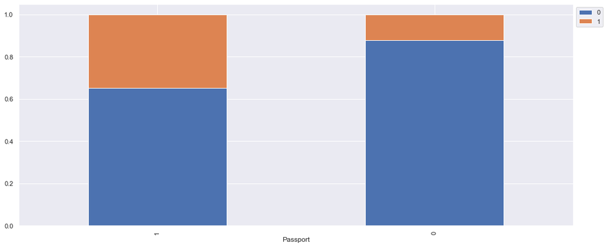

```python
stacked_plot(data['Passport'])
```

- Customers that have `Passport` have a higher success rate on ProdTaken.

### PitchSatisfactionScore vs Prod Taken

```
ProdTaken                  0    1   All
PitchSatisfactionScore
All                     3968  920  4888
3                       1162  316  1478
5                        760  210   970
4                        750  162   912
1                        798  144   942
2                        498   88   586
------------------------------------------------------------------------------------------------------------------------
```

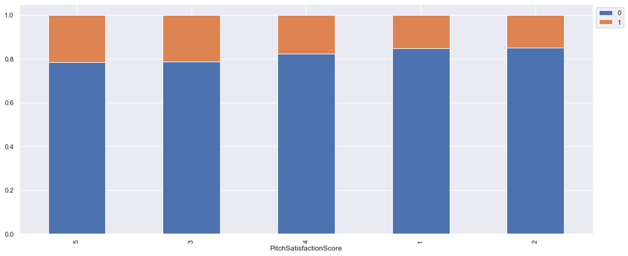

```python
stacked_plot(data['PitchSatisfactionScore'])
```

- There is no major diference in `PitchSatisfactionScore` with regard to ProdTaken.

### OwnCar vs Prod Taken

```
ProdTaken     0    1   All
OwnCar
All        3968  920  4888
1          2472  560  3032
0          1496  360  1856
------------------------------------------------------------------------------------------------------------------------
```

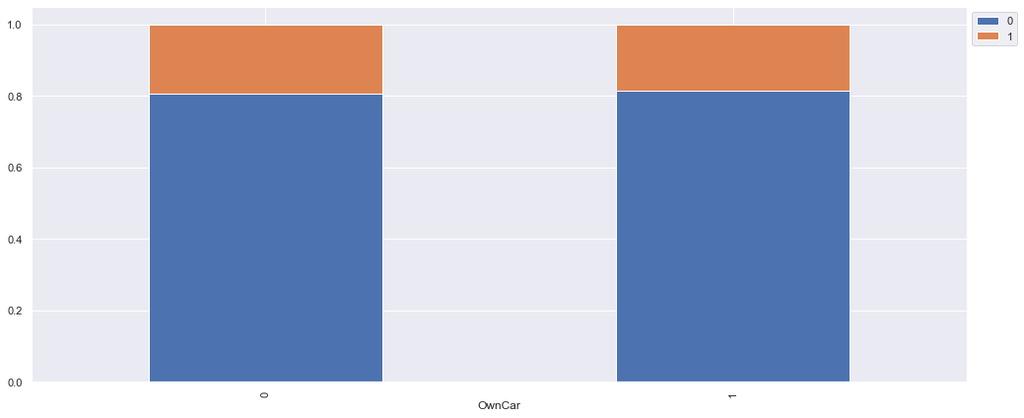

```python
stacked_plot(data['OwnCar'])
```

- There is no major diference in `OwnCar` with regard to ProdTaken.

### NumberOfChildrenVisiting vs Prod Taken

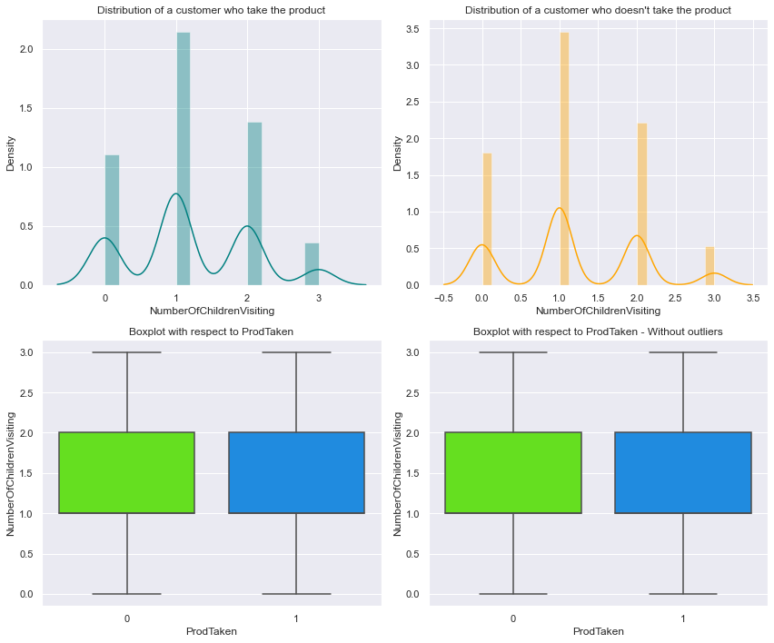

```python
dist_catplot('NumberOfChildrenVisiting')
```

- There is no major diference in `NumberOfChildrenVisiting` with regard to ProdTaken.

### Designation vs Prod Taken

```
ProdTaken          0    1   All
Designation
All             3968  920  4888
Executive       1290  552  1842
Manager         1528  204  1732
Senior Manager   618  124   742
AVP              322   20   342
VP               210   20   230
------------------------------------------------------------------------------------------------------------------------
```

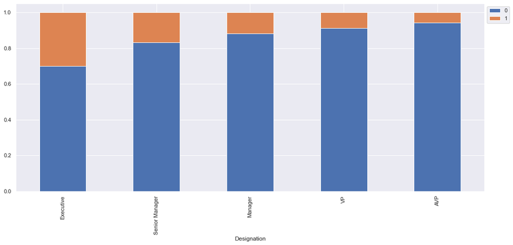

```python
stacked_plot(data['Designation'])
```

### MonthlyIncome vs Prod Taken

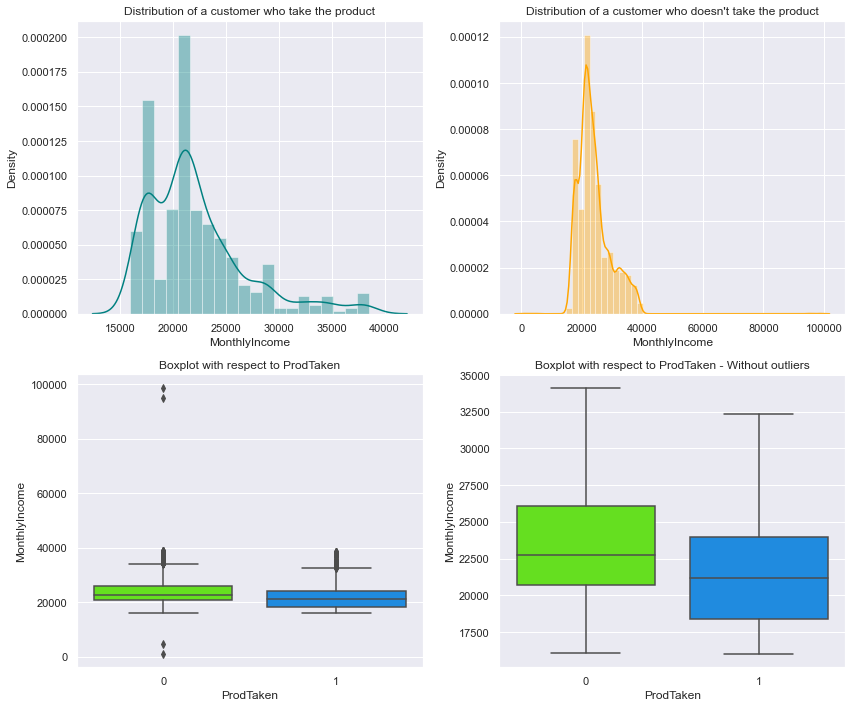

```python
dist_catplot('MonthlyIncome')
```

- Those customers who have an income higher than 20k-27k dollars are customers who will not take ProdTaken.
- Income seems to be a significant predictor as it provides good separation between two classes.

## Multivariate analysis

Analys variables with good and high correlation with regards to ProdTaken.

- NumberOfChildrenVisiting/NumberOfPersonVisiting
- NumberOfFollowups/NumberOfPersonVisiting
- NumberOfFollowups/NumberOfChildrenVisiting
- NumberOfTrips/NumberOfPersonVisiting
- NumberOfChildrenVisiting/MonthlyIncome
- NumberOfPersonVisiting/MonthlyIncome

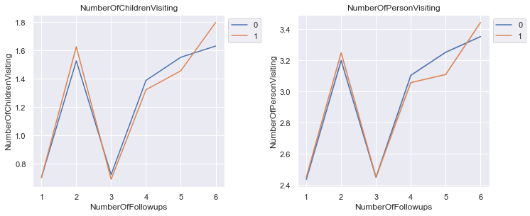

```python
cols = data[['NumberOfChildrenVisiting','NumberOfPersonVisiting']].columns.tolist()
plt.figure(figsize=(15,12))
for i, variable in enumerate(cols):
                     plt.subplot(3,3,i+1)
                     sns.lineplot(data['NumberOfFollowups'],data[variable],hue=data['ProdTaken'],ci=0)
                     plt.tight_layout()
                     plt.title(variable)
                     plt.legend(bbox_to_anchor=(1, 1))
plt.show()
```

- When visualizing difference bewteen NumberOfChildrenVisiting and NumberOfPersonVisiting in regards to NumberOfFollowups and Prod Taken, there really is no significant difference. This could be a sign of Multicollinearity.

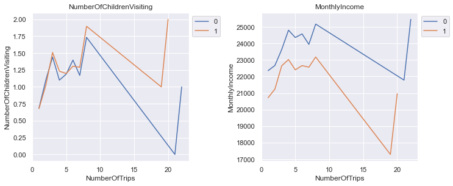

```python
cols = data[['NumberOfChildrenVisiting','MonthlyIncome']].columns.tolist()
plt.figure(figsize=(15,12))
for i, variable in enumerate(cols):
                     plt.subplot(3,3,i+1)
                     sns.lineplot(data['NumberOfTrips'],data[variable],hue=data['ProdTaken'],ci=0)
                     plt.tight_layout()
                     plt.title(variable)
                     plt.legend(bbox_to_anchor=(1, 1))
plt.show()
```

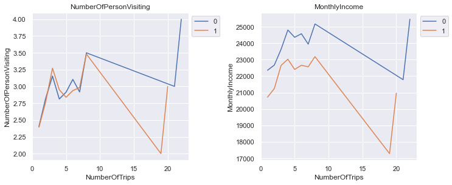

```python
cols = data[['NumberOfPersonVisiting','MonthlyIncome']].columns.tolist()
plt.figure(figsize=(15,12))
for i, variable in enumerate(cols):
                     plt.subplot(3,3,i+1)
                     sns.lineplot(data['NumberOfTrips'],data[variable],hue=data['ProdTaken'],ci=0)
                     plt.tight_layout()
                     plt.title(variable)
                     plt.legend(bbox_to_anchor=(1, 1))
plt.show()
```

- There is a difference between NumberOfPersonsVisiting and MonthlyIncome, in regards to NumberOfTrips and ProdTaken.

# Data Pre-processing

### Null treatment

- Out of 4888 rows, the following columns have null values

```python
data.isnull().sum()
```

```
ProdTaken                     0
Age                         226
TypeofContact                25
CityTier                      0
DurationOfPitch             251
Occupation                    0
Gender                        0
NumberOfPersonVisiting        0
NumberOfFollowups            45
ProductPitched                0
PreferredPropertyStar        26
MaritalStatus                 0
NumberOfTrips               140
Passport                      0
PitchSatisfactionScore        0
OwnCar                        0
NumberOfChildrenVisiting     66
Designation                   0
MonthlyIncome               233
dtype: int64
```

#### Treat Age nulls

```python
data.Age.unique()
```

```
[41.0, 49.0, 37.0, 33.0, NaN, ..., 52.0, 47.0, 18.0, 60.0, 61.0]
Length: 45
Categories (44, float64): [41.0, 49.0, 37.0, 33.0, ..., 47.0, 18.0, 60.0, 61.0]
```

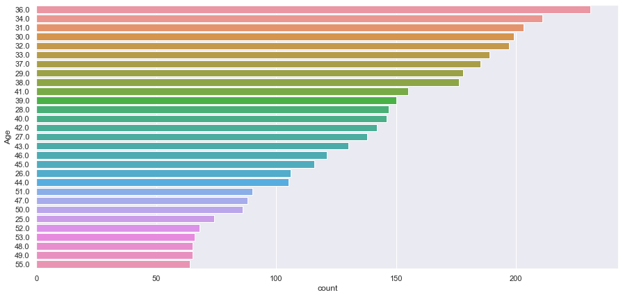

```python
plt.figure(figsize=(15, 7))
sns.countplot(y="Age", data=data, order=data["Age"].value_counts().index[1:30])
```

```python
data.Age.mode()
```

```
0    35.0
Name: Age, dtype: category
Categories (44, float64): [18.0, 19.0, 20.0, 21.0, ..., 58.0, 59.0, 60.0, 61.0]
```

```python
data['Age'] = data['Age'].fillna(data['Age'].mode()[0])
```

#### Treat TypeofContact nulls

```python
data['TypeofContact'] = data['TypeofContact'].cat.add_categories('Unknown')
data['TypeofContact'].fillna('Unknown', inplace =True)
```

```
Top:Self Enquiry
Freq:3444
```

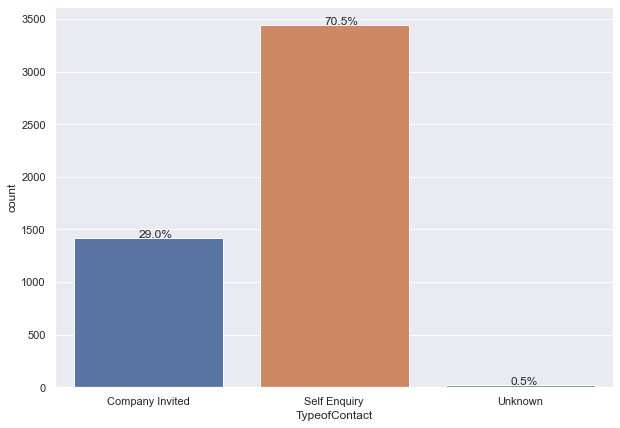

```python
bar_count_pct(data.TypeofContact)
```

#### Treat DurationOfPitch nulls

```python
data['DurationOfPitch'] = data['DurationOfPitch'].fillna(data['DurationOfPitch'].mean())
```

#### Treat NumberOfFollowups nulls

```python
data['NumberOfFollowups'] = data['NumberOfFollowups'].fillna(data['NumberOfFollowups'].mode()[0])
```

#### Treat PreferredPropertyStar nulls

```python
data['PreferredPropertyStar'] = data['PreferredPropertyStar'].fillna(data['PreferredPropertyStar'].mode()[0])
```

#### Treat NumberOfTrips nulls

```python
data['NumberOfTrips'] = data['NumberOfTrips'].fillna(data['NumberOfTrips'].mode()[0])
```

#### Treat NumberOfChildrenVisiting nulls

```python
data['NumberOfChildrenVisiting'] = data['NumberOfChildrenVisiting'].fillna(data['NumberOfChildrenVisiting'].mode()[0])
```

#### Treat MonthlyIncome nulls

```python
data['MonthlyIncome'] = data['MonthlyIncome'].fillna(data['MonthlyIncome'].mean())
```

```python
data.isnull().sum()
```

```
ProdTaken                   0
Age                         0
TypeofContact               0
CityTier                    0
DurationOfPitch             0
Occupation                  0
Gender                      0
NumberOfPersonVisiting      0
NumberOfFollowups           0
ProductPitched              0
PreferredPropertyStar       0
MaritalStatus               0
NumberOfTrips               0
Passport                    0
PitchSatisfactionScore      0
OwnCar                      0
NumberOfChildrenVisiting    0
Designation                 0
MonthlyIncome               0
dtype: int64
```

- There are no null values now

### Outlier treatment

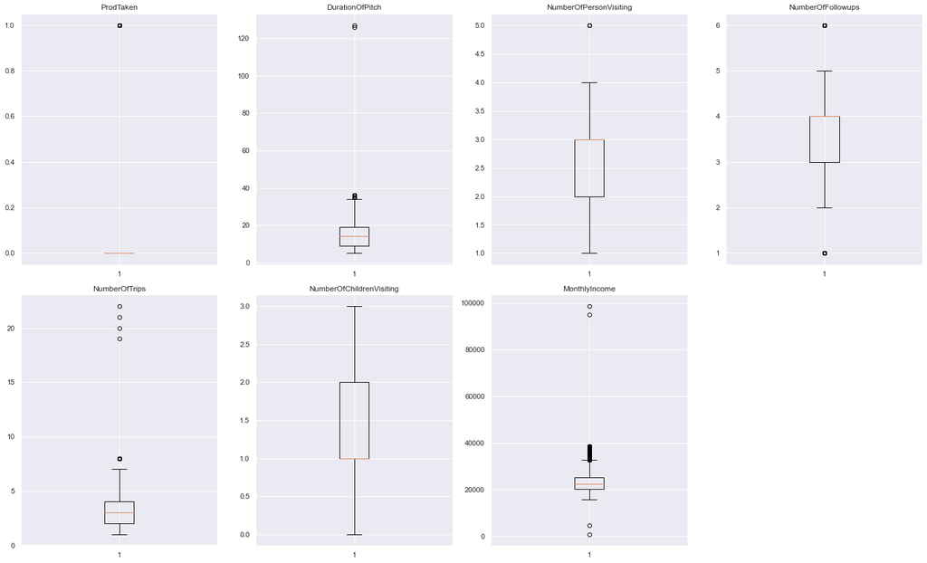

```python
numerical_col = data.select_dtypes(include=np.number).columns.tolist()

plt.figure(figsize=(20,30))

for i, variable in enumerate(numerical_col):
                     plt.subplot(5,4,i+1)
                     plt.boxplot(data[variable],whis=1.5)
                     plt.tight_layout()
                     plt.title(variable)

plt.show()
```

- We will remove `ProdTaken` from outlier treatment since this is a boolean, and also is the dependant variable.

```python
def treat_outliers(df,col):
    '''
    treats outliers in a varaible
    col: str, name of the numerical varaible
    df: data frame
    col: name of the column
    '''
    Q1=df[col].quantile(0.25) # 25th quantile
    Q3=df[col].quantile(0.75)  # 75th quantile
    IQR=Q3-Q1
    Lower_Whisker = Q1 - 1.5*IQR
    Upper_Whisker = Q3 + 1.5*IQR
    df[col] = np.clip(df[col], Lower_Whisker, Upper_Whisker) # all the values samller than Lower_Whisker will be assigned value of Lower_whisker
                                                            # and all the values above upper_whishker will be assigned value of upper_Whisker
    return df

def treat_outliers_all(df, col_list):
    '''
    treat outlier in all numerical varaibles
    col_list: list of numerical varaibles
    df: data frame
    '''
    for c in col_list:
        df = treat_outliers(df,c)

    return df
```

```python
numerical_col = data.select_dtypes(include=np.number).columns.tolist()# getting list of numerical columns


# items to be removed
unwanted= {'ProdTaken'} # these column have very few non zero observation , doing outlier treatment would remove those observation so we are keeping it as it is

numerical_col = [ele for ele in numerical_col if ele not in unwanted]
data = treat_outliers_all(data,numerical_col)
```

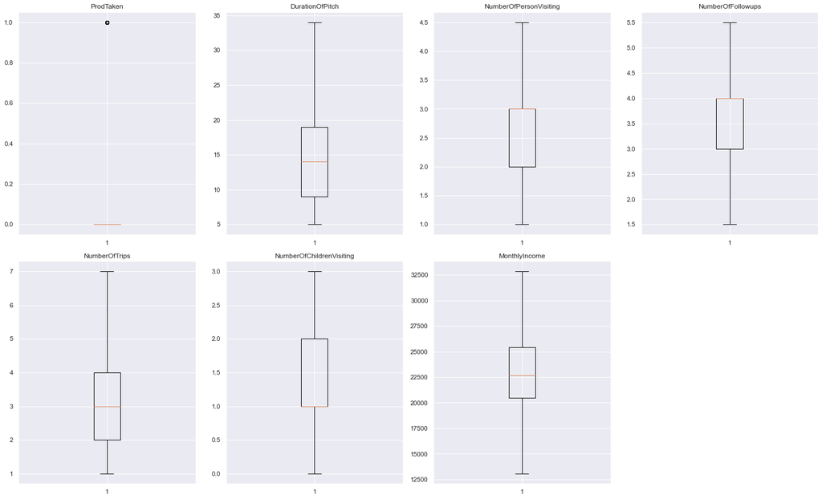

```python
numerical_col = data.select_dtypes(include=np.number).columns.tolist()

plt.figure(figsize=(20,30))

for i, variable in enumerate(numerical_col):
                     plt.subplot(5,4,i+1)
                     plt.boxplot(data[variable],whis=1.5)
                     plt.tight_layout()
                     plt.title(variable)

plt.show()
```

- There are no outliers now

### Transform Age into bigger groups

```python
def age_grouping(age):
        return (age//10)*10
```

```python
data['AgeGroup'] = data['Age'].apply(age_grouping)

data.AgeGroup.unique()
```

```
array([40., 30., 50., 20., 10., 60.])
```

```python
data = data.drop(['Age'], axis=1)
```

```
AgeGroup
 30.0    0.450900
40.0    0.231792
20.0    0.177987
50.0    0.122136
10.0    0.009411
60.0    0.007774
Name: AgeGroup, dtype: float64

Top:30.0
Freq:2204
```

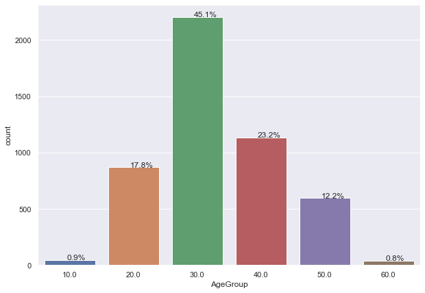

```python
print('AgeGroup\n' , data['AgeGroup'].value_counts(normalize=True) , '\n')
bar_count_pct(data.AgeGroup)
```

- Now it is more clear as to what age group is most prevalent in the dataset.
- Finally, let convert ProdTaken to category so it is handled correctly

```python
data['ProdTaken'] = data.ProdTaken.astype('category')
```

```python
data.info()
```

```
<class 'pandas.core.frame.DataFrame'>
RangeIndex: 4888 entries, 0 to 4887
Data columns (total 19 columns):
 #   Column                    Non-Null Count  Dtype
---  ------                    --------------  -----
 0   ProdTaken                 4888 non-null   category
 1   TypeofContact             4888 non-null   category
 2   CityTier                  4888 non-null   category
 3   DurationOfPitch           4888 non-null   float64
 4   Occupation                4888 non-null   category
 5   Gender                    4888 non-null   object
 6   NumberOfPersonVisiting    4888 non-null   float64
 7   NumberOfFollowups         4888 non-null   float64
 8   ProductPitched            4888 non-null   category
 9   PreferredPropertyStar     4888 non-null   category
 10  MaritalStatus             4888 non-null   category
 11  NumberOfTrips             4888 non-null   float64
 12  Passport                  4888 non-null   category
 13  PitchSatisfactionScore    4888 non-null   category
 14  OwnCar                    4888 non-null   category
 15  NumberOfChildrenVisiting  4888 non-null   float64
 16  Designation               4888 non-null   category
 17  MonthlyIncome             4888 non-null   float64
 18  AgeGroup                  4888 non-null   float64
dtypes: category(11), float64(7), object(1)
memory usage: 359.7+ KB
```

# Model building - Bagging

## Split the Data

- Because theis a significant imbalance in the distribution of the target classes (18% success on ProdTaken vs 82%), we will use stratified sampling to ensure that relative class frequencies are approximately preserved in train and test sets.
- We will be using the stratify parameter in the train_test_split function.

```python
#X = creditData.drop("default" , axis=1)
#y = creditData.pop("default")

X = data.drop(['ProdTaken'],axis=1)
X = pd.get_dummies(X,drop_first=True)
#y = data['ProdTaken'].apply(lambda x : 1 if x=='Yes' else 0)
y = data.pop('ProdTaken')
```

```python
#X_train, X_test, y_train, y_test = train_test_split(X, y, test_size=.30, random_state=1,stratify=y)

# Splitting data into training and test set:
X_train, X_test, y_train, y_test =train_test_split(X, y, test_size=0.3, random_state=1,stratify=y)
print(X_train.shape, X_test.shape)
```

```
(3421, 34) (1467, 34)
```

### Create Functions

```python
##  Function to calculate recall score
def get_recall_score(model,flag=True):
    '''
    model : classifier to predict values of X

    '''
    a = [] # defining an empty list to store train and test results
    pred_train = model.predict(X_train)
    pred_test = model.predict(X_test)
    train_recall = metrics.recall_score(y_train,pred_train)
    test_recall = metrics.recall_score(y_test,pred_test)
    a.append(train_recall) # adding train recall to list
    a.append(test_recall) # adding test recall to list
    if flag == True: # If the flag is set to True then only the following print statements will be dispayed
        print("Recall on training set : ",metrics.recall_score(y_train,pred_train))
        print("Recall on test set : ",metrics.recall_score(y_test,pred_test))

    return a # returning the list with train and test scores
```

```python
##  Function to calculate precision score
def get_precision_score(model,flag=True):
    '''
    model : classifier to predict values of X

    '''
    b = []  # defining an empty list to store train and test results
    pred_train = model.predict(X_train)
    pred_test = model.predict(X_test)
    train_precision = metrics.precision_score(y_train,pred_train)
    test_precision = metrics.precision_score(y_test,pred_test)
    b.append(train_precision) # adding train precision to list
    b.append(test_precision) # adding test precision to list
    if flag == True: # If the flag is set to True then only the following print statements will be dispayed
        print("Precision on training set : ",metrics.precision_score(y_train,pred_train))
        print("Precision on test set : ",metrics.precision_score(y_test,pred_test))

    return b # returning the list with train and test scores
```

```python
##  Function to calculate accuracy score
def get_accuracy_score(model,flag=True):
    '''
    model : classifier to predict values of X

    '''
    c = [] # defining an empty list to store train and test results
    train_acc = model.score(X_train,y_train)
    test_acc = model.score(X_test,y_test)
    c.append(train_acc) # adding train accuracy to list
    c.append(test_acc) # adding test accuracy to list
    if flag == True: # If the flag is set to True then only the following print statements will be dispayed
        print("Accuracy on training set : ",model.score(X_train,y_train))
        print("Accuracy on test set : ",model.score(X_test,y_test))

    return c # returning the list with train and test scores
```

```python
def make_confusion_matrix(model,y_actual,labels=[1, 0]):
    '''
    model : classifier to predict values of X
    y_actual : ground truth

    '''
    y_predict = model.predict(X_test)
    cm=metrics.confusion_matrix( y_actual, y_predict, labels=[0, 1])
    df_cm = pd.DataFrame(cm, index = [i for i in ["Actual - No","Actual - Yes"]],
                  columns = [i for i in ['Predicted - No','Predicted - Yes']])
    group_counts = ["{0:0.0f}".format(value) for value in
                cm.flatten()]
    group_percentages = ["{0:.2%}".format(value) for value in
                         cm.flatten()/np.sum(cm)]
    labels = [f"{v1}\n{v2}" for v1, v2 in
              zip(group_counts,group_percentages)]
    labels = np.asarray(labels).reshape(2,2)
    plt.figure(figsize = (10,7))
    sns.heatmap(df_cm, annot=labels,fmt='')
    plt.ylabel('True label')
    plt.xlabel('Predicted label')
```

## Build Decision Tree Model

- We will build our model using the DecisionTreeClassifier function. Using default 'gini' criteria to split.
- We will pass a dictionary {0:0.18,1:0.82} to the model to specify the weight of each class and the decision tree will give more weightage to class 1.

```python
dtree = DecisionTreeClassifier(criterion='gini',class_weight={0:0.18,1:0.82},random_state=1)
```

```python
dtree.fit(X_train, y_train)
```

```
DecisionTreeClassifier(class_weight={0: 0.18, 1: 0.82}, random_state=1)
```

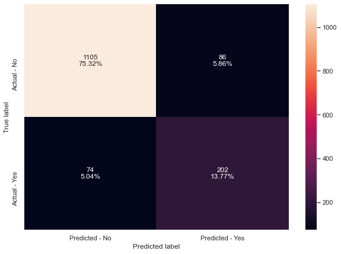

```python
make_confusion_matrix(dtree,y_test)
```

Confusion Matrix -

- Consumer took the product and the model predicted it correctly that ProdTaken=1 : True Positive (observed=1,predicted=1)
- Consumer didn't take the product and the model predicted ProdTaken=1 : False Positive (observed=0,predicted=1)
- Consumer didn't take the product and the model predicted ProdTaken=0 : True Negative (observed=0,predicted=0)
- Consumer took the product and the model predicted that ProdTaken=0 : False Negative (observed=1,predicted=0)

```python
dtree_acc = get_accuracy_score(dtree)
dtree_recall = get_recall_score(dtree)
dtree_precision = get_precision_score(dtree)
```

```
Accuracy on training set :  1.0
Accuracy on test set :  0.89093387866394
Recall on training set :  1.0
Recall on test set :  0.7318840579710145
Precision on training set :  1.0
Precision on test set :  0.7013888888888888
```

- Decision Treemodel is overfitting on the training set and is performing poorly on the test set in terms of recall.

## Build Bagging Classifier Model

```python
bagging = BaggingClassifier(random_state=1)
bagging.fit(X_train,y_train)
```

```
BaggingClassifier(random_state=1)
```

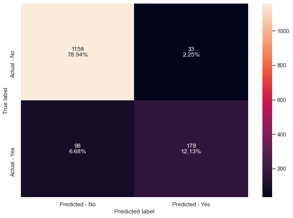

```python
make_confusion_matrix(bagging,y_test)
```

```python
bagging_acc = get_accuracy_score(bagging)
bagging_recall = get_recall_score(bagging)
bagging_precision = get_precision_score(bagging)
```

```
Accuracy on training set :  0.9944460684010523
Accuracy on test set :  0.9107021131561008
Recall on training set :  0.9720496894409938
Recall on test set :  0.644927536231884
Precision on training set :  0.9984051036682615
Precision on test set :  0.8436018957345972
```

- Bagging classifier is overfitting on the training set and is performing poorly on the test set in terms of recall.

### Bagging Classifier with weighted decision tree

```python
bagging_wt = BaggingClassifier(base_estimator=DecisionTreeClassifier(criterion='gini',class_weight={0:0.18,1:0.82},random_state=1),random_state=1)
bagging_wt.fit(X_train,y_train)
```

```
BaggingClassifier(base_estimator=DecisionTreeClassifier(class_weight={0: 0.18,
                                                                      1: 0.82},
                                                        random_state=1),
                  random_state=1)
```

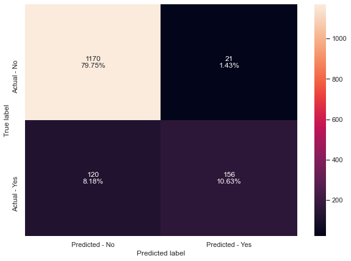

```python
make_confusion_matrix(bagging_wt,y_test)
```

```python
wt_bagging_acc = get_accuracy_score(bagging_wt)
wt_bagging_recall = get_recall_score(bagging_wt)
wt_bagging_precision = get_precision_score(bagging_wt)
```

```
Accuracy on training set :  0.9956153171587255
Accuracy on test set :  0.9038854805725971
Recall on training set :  0.9782608695652174
Recall on test set :  0.5652173913043478
Precision on training set :  0.9984152139461173
Precision on test set :  0.8813559322033898
```

- Bagging classifier with a weighted decision tree is giving very good accuracy and prediction but is not able to generalize well on test data in terms of recall.

## Build Random Forest Model

```python
rf = RandomForestClassifier(random_state=1)
rf.fit(X_train,y_train)
```

```
RandomForestClassifier(random_state=1)
```

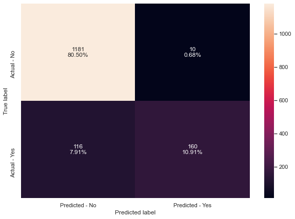

```python
make_confusion_matrix(rf,y_test)
```

```python
rf_acc = get_accuracy_score(rf)
rf_recall = get_recall_score(rf)
rf_precision = get_precision_score(rf)
```

```
Accuracy on training set :  1.0
Accuracy on test set :  0.9141104294478528
Recall on training set :  1.0
Recall on test set :  0.5797101449275363
Precision on training set :  1.0
Precision on test set :  0.9411764705882353
```

- Random Forest has performed well in terms of accuracy and precision, but it is not able to generalize well on the test data in terms of recall.

### Random forest with class weights

```python
rf_wt = RandomForestClassifier(class_weight={0:0.18,1:0.82}, random_state=1)
rf_wt.fit(X_train,y_train)
```

```
RandomForestClassifier(class_weight={0: 0.18, 1: 0.82}, random_state=1)
```

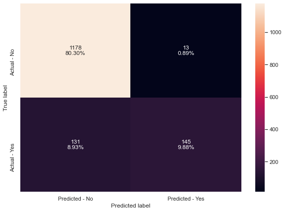

```python
make_confusion_matrix(rf_wt,y_test)
```

```python
wt_rf_acc = get_accuracy_score(rf_wt)
wt_rf_recall = get_recall_score(rf_wt)
wt_rf_precision = get_precision_score(rf_wt)
```

```
Accuracy on training set :  1.0
Accuracy on test set :  0.901840490797546
Recall on training set :  1.0
Recall on test set :  0.5253623188405797
Precision on training set :  1.0
Precision on test set :  0.9177215189873418
```

- There is not much improvement in metrics of weighted random forest as compared to the unweighted random forest.
- Random Forest with Weighted Tree has performed well in terms of accuracy and precision, but it is not able to generalize well on the test data in terms of recall.

## Tuning Models

### Using GridSearch for Hyperparameter tuning model

- Grid search is a tuning technique that attempts to compute the optimum values of hyperparameters.
- It is an exhaustive search that is performed on a the specific parameter values of a model.

#### Tuning Decision Tree

```python
# Choose the type of classifier.
dtree_estimator = DecisionTreeClassifier(class_weight={0:0.18,1:0.82},random_state=1)

# Grid of parameters to choose from - this will perform 2800 tests
parameters = {'max_depth': np.arange(2,30),
              'min_samples_leaf': [1, 2, 5, 7, 10],
              'max_leaf_nodes' : [2, 3, 5, 10,15],
              'min_impurity_decrease': [0.0001,0.001,0.01,0.1]
             }

# Type of scoring used to compare parameter combinations
scorer = metrics.make_scorer(metrics.recall_score)

# Run the grid search
grid_obj = GridSearchCV(dtree_estimator, parameters, scoring=scorer)
grid_obj = grid_obj.fit(X_train, y_train)

# Set the clf to the best combination of parameters
dtree_estimator = grid_obj.best_estimator_

# Fit the best algorithm to the data.
dtree_estimator.fit(X_train, y_train)
```

```
DecisionTreeClassifier(class_weight={0: 0.18, 1: 0.82}, max_depth=2,
                       max_leaf_nodes=2, min_impurity_decrease=0.1,
                       random_state=1)
```

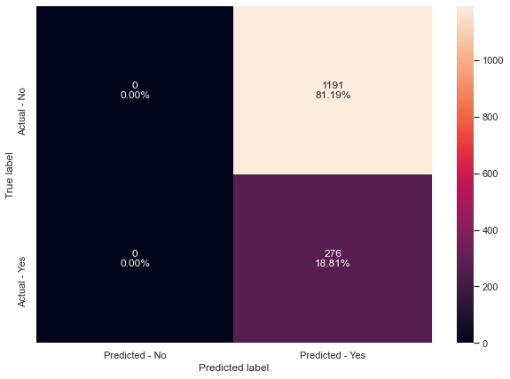

```python
make_confusion_matrix(dtree_estimator,y_test)
```

```python
tuned_dtree_acc = get_accuracy_score(dtree_estimator)
tuned_dtree_recall = get_recall_score(dtree_estimator)
tuned_dtree_precision = get_precision_score(dtree_estimator)
```

```
Accuracy on training set :  0.1882490499853844
Accuracy on test set :  0.18813905930470348
Recall on training set :  1.0
Recall on test set :  1.0
Precision on training set :  0.1882490499853844
Precision on test set :  0.18813905930470348
```

- Overfitting in decision tree has reduced Accuracy and Precision, but the Recall has improved. This is an indication that overall the model is making many mistakes.

#### Tuning Bagging Classifier

```python
# grid search for bagging classifier
cl1 = DecisionTreeClassifier(class_weight={0:0.18,1:0.82},random_state=1)
param_grid = {'base_estimator':[cl1],
              'n_estimators':[5,7,15,51,101],
              'max_features': [0.7,0.8,0.9,1]
             }

grid = GridSearchCV(BaggingClassifier(random_state=1,bootstrap=True), param_grid=param_grid, scoring = 'recall', cv = 5)
grid.fit(X_train, y_train)
```

```
GridSearchCV(cv=5, estimator=BaggingClassifier(random_state=1),
             param_grid={'base_estimator': [DecisionTreeClassifier(class_weight={0: 0.18,
                                                                                 1: 0.82},
                                                                   random_state=1)],
                         'max_features': [0.7, 0.8, 0.9, 1],
                         'n_estimators': [5, 7, 15, 51, 101]},
             scoring='recall')
```

```python
## getting the best estimator
bagging_estimator  = grid.best_estimator_
bagging_estimator.fit(X_train,y_train)
```

```
BaggingClassifier(base_estimator=DecisionTreeClassifier(class_weight={0: 0.18,
                                                                      1: 0.82},
                                                        random_state=1),
                  max_features=1, n_estimators=51, random_state=1)
```

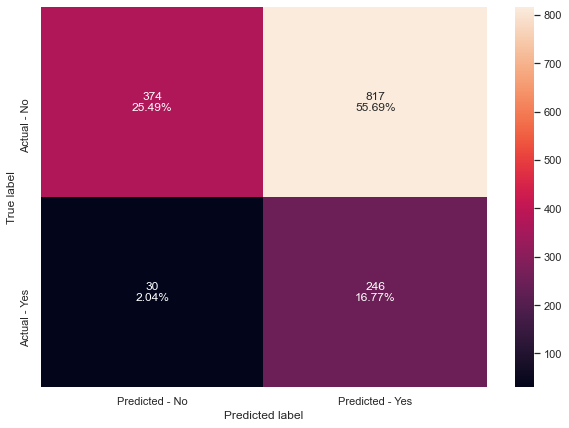

```python
make_confusion_matrix(bagging_estimator,y_test)
```

```python
tuned_bagging_acc= get_accuracy_score(bagging_estimator)
tuned_bagging_recall = get_recall_score(bagging_estimator)
tuned_bagging_precision = get_precision_score(bagging_estimator)
```

```
Accuracy on training set :  0.4811458637825197
Accuracy on test set :  0.4226312201772324
Recall on training set :  0.9611801242236024
Recall on test set :  0.8913043478260869
Precision on training set :  0.2612916842549599
Precision on test set :  0.23142050799623706
```

- Recall has improved but the accuracy and precision of the model has dropped drastically which is an indication that overall the model is making many mistakes.

#### Tuning Random Forest

```python
# Choose the type of classifier.
rf_estimator = RandomForestClassifier(random_state=1)

# Grid of parameters to choose from
parameters = {
        "n_estimators": [110,251],
        "min_samples_leaf": np.arange(1, 6,1),
        "max_features": [0.7,0.9,'log2','auto'],
        "max_samples": [0.7,0.9,None],
}


# Run the grid search
grid_obj = GridSearchCV(rf_estimator, parameters, scoring='recall',cv=5)
grid_obj = grid_obj.fit(X_train, y_train)

# Set the clf to the best combination of parameters
rf_estimator = grid_obj.best_estimator_

# Fit the best algorithm to the data.
rf_estimator.fit(X_train, y_train)
```

```
RandomForestClassifier(max_features=0.7, n_estimators=251, random_state=1)
```

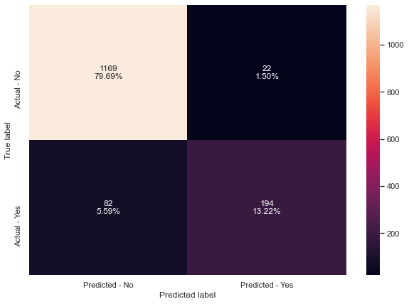

```python
make_confusion_matrix(rf_estimator,y_test)
```

```python
tuned_rf_acc = get_accuracy_score(rf_estimator)
tuned_rf_recall = get_recall_score(rf_estimator)
tuned_rf_precision = get_precision_score(rf_estimator)
```

```
Accuracy on training set :  1.0
Accuracy on test set :  0.929107021131561
Recall on training set :  1.0
Recall on test set :  0.7028985507246377
Precision on training set :  1.0
Precision on test set :  0.8981481481481481
```

## Comparing all the models

```python
# defining list of models
models = [dtree,dtree_estimator,bagging,bagging_wt,bagging_estimator,rf,rf_wt,rf_estimator]
# defining empty lists to add train and test results
acc_train = []
acc_test = []
recall_train = []
recall_test = []
precision_train = []
precision_test = []

# looping through all the models to get the accuracy,recall and precision scores
for model in models:
    # accuracy score
    j = get_accuracy_score(model,False)
    acc_train.append(j[0])
    acc_test.append(j[1])
    # recall score
    k = get_recall_score(model,False)
    recall_train.append(k[0])
    recall_test.append(k[1])
    # precision score
    l = get_precision_score(model,False)
    precision_train.append(l[0])
    precision_test.append(l[1])
```

```python
comparison_frame = pd.DataFrame({'Model':['Decision Tree','Tuned Decision Tree','Bagging Classifier',
                                          'Weighted Bagging Classifier','Tuned Bagging Classifier',
                                          'Random Forest','Weighted Random Forest','Tuned Random Forest'],
                                          'Train_Accuracy': acc_train,
                                          'Test_Accuracy': acc_test,
                                          'Train_Recall': recall_train,
                                          'Test_Recall': recall_test,
                                          'Train_Precision': precision_train,
                                          'Test_Precision': precision_test})
comparison_frame
```

|  | Model | Train_Accuracy | Test_Accuracy | Train_Recall | Test_Recall | Train_Precision | Test_Precision |
| --- | --- | --- | --- | --- | --- | --- | --- |
| 0 | Decision Tree | 1.000000 | 0.890934 | 1.000000 | 0.731884 | 1.000000 | 0.701389 |
| 1 | Tuned Decision Tree | 0.188249 | 0.188139 | 1.000000 | 1.000000 | 0.188249 | 0.188139 |
| 2 | Bagging Classifier | 0.994446 | 0.910702 | 0.972050 | 0.644928 | 0.998405 | 0.843602 |
| 3 | Weighted Bagging Classifier | 0.995615 | 0.903885 | 0.978261 | 0.565217 | 0.998415 | 0.881356 |
| 4 | Tuned Bagging Classifier | 0.481146 | 0.422631 | 0.961180 | 0.891304 | 0.261292 | 0.231421 |
| 5 | Random Forest | 1.000000 | 0.914110 | 1.000000 | 0.579710 | 1.000000 | 0.941176 |
| 6 | Weighted Random Forest | 1.000000 | 0.901840 | 1.000000 | 0.525362 | 1.000000 | 0.917722 |
| 7 | Tuned Random Forest | 1.000000 | 0.929107 | 1.000000 | 0.702899 | 1.000000 | 0.898148 |

## Feature importance of Random Forest with Tuning

```python
# importance of features in the tree building ( The importance of a feature is computed as the
#(normalized) total reduction of the criterion brought by that feature. It is also known as the Gini importance )

print (pd.DataFrame(rf_estimator.feature_importances_, columns = ["Imp"], index = X_train.columns).sort_values(by = 'Imp', ascending = False))
```

```
                                  Imp
MonthlyIncome                0.149993
DurationOfPitch              0.118809
Passport_1                   0.067302
NumberOfTrips                0.065421
NumberOfFollowups            0.059158
AgeGroup                     0.055359
Designation_Executive        0.050722
CityTier_3                   0.038826
MaritalStatus_Single         0.032236
NumberOfPersonVisiting       0.028049
NumberOfChildrenVisiting     0.027526
Gender_Male                  0.026446
PreferredPropertyStar_5.0    0.024879
PitchSatisfactionScore_3     0.022245
TypeofContact_Self Enquiry   0.022170
MaritalStatus_Unmarried      0.020512
PitchSatisfactionScore_4     0.019415
PreferredPropertyStar_4.0    0.018364
OwnCar_1                     0.018127
Occupation_Large Business    0.017021
PitchSatisfactionScore_5     0.016978
Occupation_Small Business    0.015879
Occupation_Salaried          0.014933
MaritalStatus_Married        0.014003
CityTier_2                   0.011154
ProductPitched_Deluxe        0.008305
Designation_Manager          0.007794
PitchSatisfactionScore_2     0.007411
ProductPitched_Standard      0.006327
Designation_Senior Manager   0.006286
ProductPitched_Super Deluxe  0.003037
ProductPitched_King          0.002246
Designation_VP               0.002162
TypeofContact_Unknown        0.000905
```

```python
feature_names = X_train.columns
```

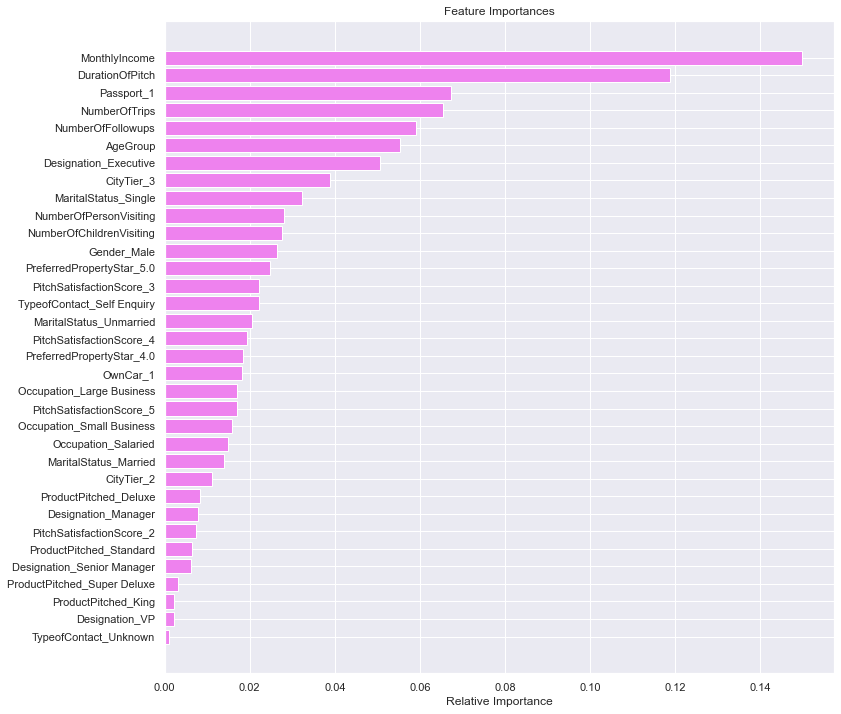

```python
importances = rf_estimator.feature_importances_
indices = np.argsort(importances)

plt.figure(figsize=(12,12))
plt.title('Feature Importances')
plt.barh(range(len(indices)), importances[indices], color='violet', align='center')
plt.yticks(range(len(indices)), [feature_names[i] for i in indices])
plt.xlabel('Relative Importance')
plt.show()
```

- `Monthlyincome` is the most important feature for prediction followed by `DurationOfPitch`, `Passport_1` and `NumberOfTrips`.

# Model building - Boosting

```python
##  Function to calculate r2_score and RMSE on train and test data
def get_model_score(model, flag=True):
    '''
    model : classifier to predict values of X

    '''
    # defining an empty list to store train and test results
    score_list=[]

    pred_train = model.predict(X_train)
    pred_test = model.predict(X_test)

    train_r2=metrics.r2_score(y_train,pred_train)
    test_r2=metrics.r2_score(y_test,pred_test)
    train_rmse=np.sqrt(metrics.mean_squared_error(y_train,pred_train))
    test_rmse=np.sqrt(metrics.mean_squared_error(y_test,pred_test))

    #Adding all scores in the list
    score_list.extend((train_r2,test_r2,train_rmse,test_rmse))

    # If the flag is set to True then only the following print statements will be dispayed, the default value is True
    if flag==True:
        print("R-sqaure on training set : ",metrics.r2_score(y_train,pred_train))
        print("R-square on test set : ",metrics.r2_score(y_test,pred_test))
        print("RMSE on training set : ",np.sqrt(metrics.mean_squared_error(y_train,pred_train)))
        print("RMSE on test set : ",np.sqrt(metrics.mean_squared_error(y_test,pred_test)))

    # returning the list with train and test scores
    return score_list
```

```python
abc = AdaBoostClassifier(random_state=1)
abc.fit(X_train,y_train)
```

```
AdaBoostClassifier(random_state=1)
```

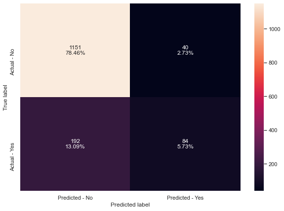

```python
make_confusion_matrix(abc,y_test)
```

```python
abc_score=get_metrics_score(abc)
```

```
Accuracy on training set :  0.842443729903537
Accuracy on test set :  0.841854124062713
Recall on training set :  0.3059006211180124
Recall on test set :  0.30434782608695654
Precision on training set :  0.6816608996539792
Precision on test set :  0.6774193548387096
```

- AdaBoost is generalizing well but it is giving very poor performance on recall.

#### Hyperparameter Tuning

```python
# Choose the type of classifier.
abc_tuned = AdaBoostClassifier(random_state=1)

# Grid of parameters to choose from
## add from article
parameters = {
    #Let's try different max_depth for base_estimator
    "base_estimator":[DecisionTreeClassifier(max_depth=1),DecisionTreeClassifier(max_depth=2),DecisionTreeClassifier(max_depth=3)],
    "n_estimators": np.arange(10,110,10),
    "learning_rate":np.arange(0.1,2,0.1)
}

# Type of scoring used to compare parameter combinations
acc_scorer = metrics.make_scorer(metrics.recall_score)

# Run the grid search
grid_obj = GridSearchCV(abc_tuned, parameters, scoring=acc_scorer,cv=5)
grid_obj = grid_obj.fit(X_train, y_train)

# Set the clf to the best combination of parameters
abc_tuned = grid_obj.best_estimator_

# Fit the best algorithm to the data.
abc_tuned.fit(X_train, y_train)
```

```
AdaBoostClassifier(base_estimator=DecisionTreeClassifier(max_depth=3),
                   learning_rate=1.5000000000000002, n_estimators=100,
                   random_state=1)
```

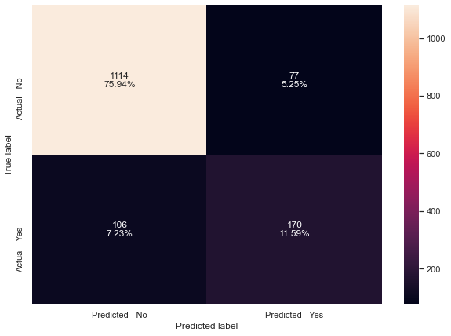

```python
make_confusion_matrix(abc_tuned,y_test)
```

```python
abc_tuned_score=get_metrics_score(abc_tuned)
```

```
Accuracy on training set :  0.9874305758550131
Accuracy on test set :  0.8752556237218814
Recall on training set :  0.953416149068323
Recall on test set :  0.6159420289855072
Precision on training set :  0.9792663476874003
Precision on test set :  0.6882591093117408
```

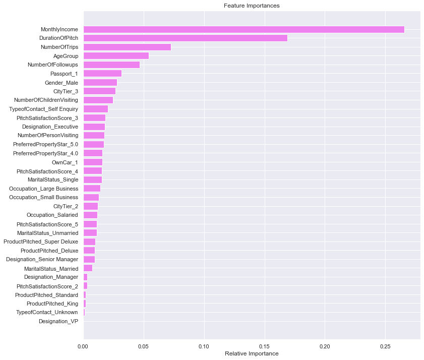

```python
importances = abc_tuned.feature_importances_
indices = np.argsort(importances)
feature_names = list(X.columns)

plt.figure(figsize=(12,12))
plt.title('Feature Importances')
plt.barh(range(len(indices)), importances[indices], color='violet', align='center')
plt.yticks(range(len(indices)), [feature_names[i] for i in indices])
plt.xlabel('Relative Importance')
plt.show()
```

- `MonthlyIncome` is the most important feature as per the tuned AdaBoost model, followed by `DurationOfPitch`, `NumberOfTrips` and `AgeGroup`.

## Gradient Boosting Classifier Model

```python
gbc_init = GradientBoostingClassifier(init=AdaBoostClassifier(random_state=1),random_state=1)
gbc_init.fit(X_train,y_train)
```

```
GradientBoostingClassifier(init=AdaBoostClassifier(random_state=1),
                           random_state=1)
```

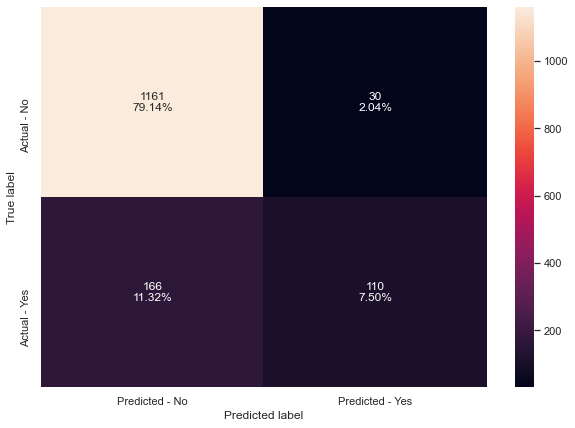

```python
make_confusion_matrix(gbc_init,y_test)
```

```python
#Using above defined function to get accuracy, recall and precision on train and test set
gbc_init_score=get_metrics_score(gbc_init)
```

```
Accuracy on training set :  0.8827828120432623
Accuracy on test set :  0.8663940013633266
Recall on training set :  0.44254658385093165
Recall on test set :  0.39855072463768115
Precision on training set :  0.8715596330275229
Precision on test set :  0.7857142857142857
```

- Gradient boosting is generalizing well and giving poor results on recall.

#### Hyperparameter Tuning

```python
# Choose the type of classifier.
gbc_tuned = GradientBoostingClassifier(init=AdaBoostClassifier(random_state=1),random_state=1)

# Grid of parameters to choose from
## add from article
parameters = {
    "n_estimators": [100,150,200],
    "subsample":[0.8,0.9,1],
    "max_features":[0.7,0.8,0.9,1]
}

# Type of scoring used to compare parameter combinations
acc_scorer = metrics.make_scorer(metrics.recall_score)

# Run the grid search
grid_obj = GridSearchCV(gbc_tuned, parameters, scoring=acc_scorer,cv=5)
grid_obj = grid_obj.fit(X_train, y_train)

# Set the clf to the best combination of parameters
gbc_tuned = grid_obj.best_estimator_

# Fit the best algorithm to the data.
gbc_tuned.fit(X_train, y_train)
```

```
GradientBoostingClassifier(init=AdaBoostClassifier(random_state=1),
                           max_features=0.9, n_estimators=200, random_state=1,
                           subsample=0.9)
```

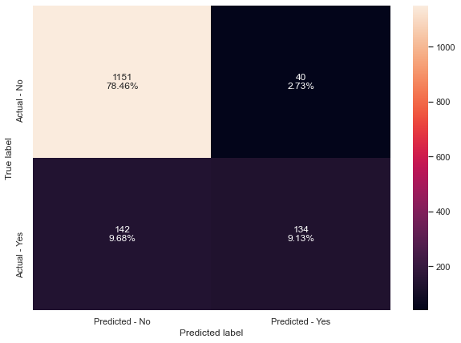

```python
make_confusion_matrix(gbc_tuned,y_test)
```

```python
#Using above defined function to get accuracy, recall and precision on train and test set
gbc_tuned_score=get_metrics_score(gbc_tuned)
```

```
Accuracy on training set :  0.9087985969014908
Accuracy on test set :  0.8759372869802318
Recall on training set :  0.562111801242236
Recall on test set :  0.4855072463768116
Precision on training set :  0.923469387755102
Precision on test set :  0.7701149425287356
```

- The model performace has not increased by much.
- The model has started to overfit the train data in terms of recall.
- The model is generalizing well but it is giving very poor performance on recall.

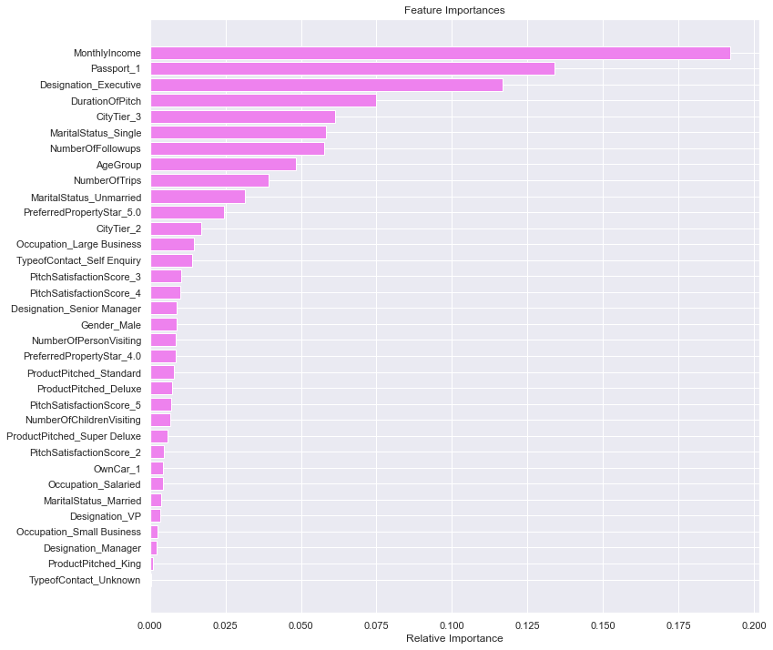

```python
importances = gbc_tuned.feature_importances_
indices = np.argsort(importances)
feature_names = list(X.columns)

plt.figure(figsize=(12,12))
plt.title('Feature Importances')
plt.barh(range(len(indices)), importances[indices], color='violet', align='center')
plt.yticks(range(len(indices)), [feature_names[i] for i in indices])
plt.xlabel('Relative Importance')
plt.show()
```

## XGBoost Classifier Model

```python
# Choose the type of classifier.
xgb_tuned = XGBClassifier(random_state=1)

# Grid of parameters to choose from
## add from
parameters = {
    "n_estimators": np.arange(10,100,30),
    "scale_pos_weight":[0,1,2],
    "subsample":[0.5,0.7,1],
    "learning_rate":[0.01,0.1,0.2],
    "gamma":[0,1,3],
    "colsample_bytree":[0.5,0.7,1],
    "colsample_bylevel":[0.5,0.7,1]
}

# Type of scoring used to compare parameter combinations
acc_scorer = metrics.make_scorer(metrics.recall_score)

# Run the grid search
grid_obj = GridSearchCV(xgb_tuned, parameters,scoring=acc_scorer,cv=5)
grid_obj = grid_obj.fit(X_train, y_train)

# Set the clf to the best combination of parameters
xgb_tuned = grid_obj.best_estimator_

# Fit the best algorithm to the data.
xgb_tuned.fit(X_train, y_train)
```

```
XGBClassifier(base_score=0.5, booster='gbtree', colsample_bylevel=1,
              colsample_bynode=1, colsample_bytree=1, gamma=1, gpu_id=-1,
              importance_type='gain', interaction_constraints='',
              learning_rate=0.2, max_delta_step=0, max_depth=6,
              min_child_weight=1, missing=nan, monotone_constraints='()',
              n_estimators=70, n_jobs=4, num_parallel_tree=1, random_state=1,
              reg_alpha=0, reg_lambda=1, scale_pos_weight=2, subsample=1,
              tree_method='exact', validate_parameters=1, verbosity=None)
```

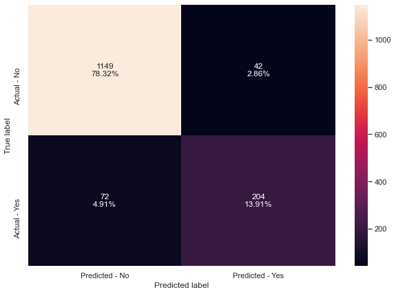

```python
make_confusion_matrix(xgb_tuned,y_test)
```

```python
#Using above defined function to get accuracy, recall and precision on train and test set
xgb_tuned_score=get_metrics_score(xgb_tuned)
```

```
Accuracy on training set :  0.9929845074539608
Accuracy on test set :  0.9222903885480572
Recall on training set :  0.9782608695652174
Recall on test set :  0.7391304347826086
Precision on training set :  0.984375
Precision on test set :  0.8292682926829268
```

- This model performs really well on all metrics. Even though Recall on test data seems a bit low, it is not that bad and all other metrics look good.

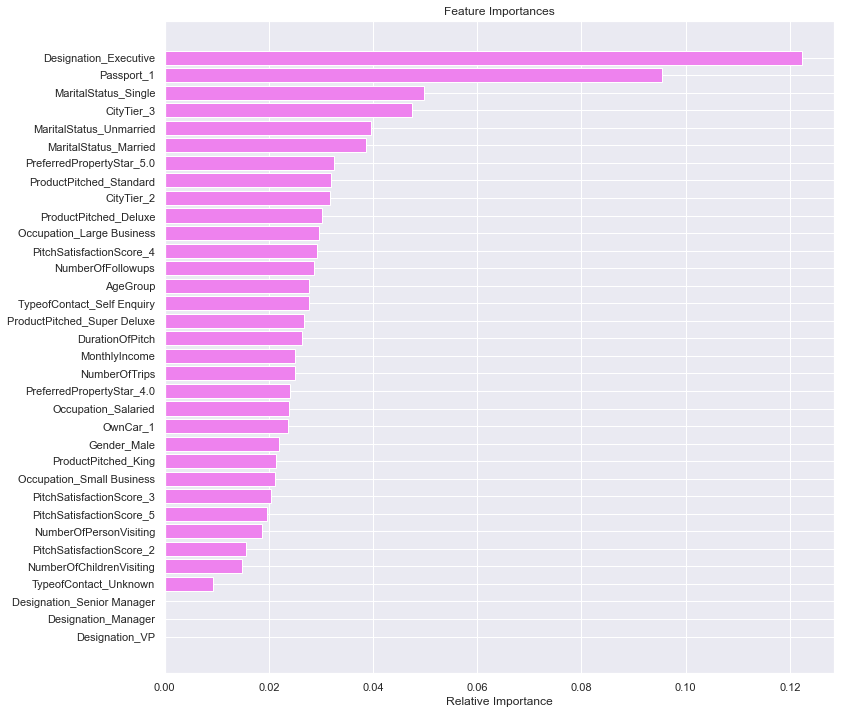

```python
importances = xgb_tuned.feature_importances_
indices = np.argsort(importances)
feature_names = list(X.columns)

plt.figure(figsize=(12,12))
plt.title('Feature Importances')
plt.barh(range(len(indices)), importances[indices], color='violet', align='center')
plt.yticks(range(len(indices)), [feature_names[i] for i in indices])
plt.xlabel('Relative Importance')
plt.show()
```

- `Designation_Executive` is the most important feature for prediction followed by `Passport_1`, `MaritalStatus_Single` and `CityTier_3`.

### Comparing all models

```python
# defining list of models
models = [abc, abc_tuned, gbc_init, gbc_tuned, xgb_tuned]

# defining empty lists to add train and test results
acc_train = []
acc_test = []
recall_train = []
recall_test = []
precision_train = []
precision_test = []

# looping through all the models to get the accuracy, precall and precision scores
for model in models:
    j = get_metrics_score(model,False)
    acc_train.append(np.round(j[0],2))
    acc_test.append(np.round(j[1],2))
    recall_train.append(np.round(j[2],2))
    recall_test.append(np.round(j[3],2))
    precision_train.append(np.round(j[4],2))
    precision_test.append(np.round(j[5],2))
```

```python
comparison_frame = pd.DataFrame({'Model':['AdaBoost with default paramters','AdaBoost Tuned',
                                          'Gradient Boosting with init=AdaBoost','Gradient Boosting Tuned',
                                          'XGBoost Tuned'],
                                          'Train_Accuracy': acc_train,'Test_Accuracy': acc_test,
                                          'Train_Recall':recall_train,'Test_Recall':recall_test,
                                          'Train_Precision':precision_train,'Test_Precision':precision_test})
comparison_frame
```

|  | Model | Train_Accuracy | Test_Accuracy | Train_Recall | Test_Recall | Train_Precision | Test_Precision |
| --- | --- | --- | --- | --- | --- | --- | --- |
| 0 | AdaBoost with default paramters | 0.84 | 0.84 | 0.31 | 0.30 | 0.68 | 0.68 |
| 1 | AdaBoost Tuned | 0.99 | 0.88 | 0.95 | 0.62 | 0.98 | 0.69 |
| 2 | Gradient Boosting with init=AdaBoost | 0.88 | 0.87 | 0.44 | 0.40 | 0.87 | 0.79 |
| 3 | Gradient Boosting Tuned | 0.91 | 0.88 | 0.56 | 0.49 | 0.92 | 0.77 |
| 4 | XGBoost Tuned | 0.99 | 0.92 | 0.98 | 0.74 | 0.98 | 0.83 |

# Business Recommendations

- Company can focus on targeting customer with these strong important features:
  - Designation_Executive
  - Passport_1
  - MaritalStatus_Single
  - CityTier_3